# Exercise 3.3.1

[Saurabh Steixner-Kumar](https://steixnerkumar.github.io/) (social): - -

# 1 Question

Exercise 3.3.1 Try the data k1 = 14, n1 = 20, k2 = 16, n2 = 20. How could you report the inference about the common rate $\theta$?

# 2 Comments/Solution

In this example of the dataset we see that the individually the k1 and k2 both present cases around the probability of 0.75 and the common rate $\theta$ is estimated also to be around 0.75. Check out the plots section.

One reasonable reporting strategy here might be to use a measure for central tendency, such as a mean, median, or mode, together with a credible interval, for instance a 95% credible interval.

The model used to calculate the required values and the plots is scripted below. Copy/pasting the given code will generate the same result on your own machine.

# 3 Code

## 3.1 libraries

The libraries required for the script and the plots.

```r
# clears workspace
rm(list=ls())
#load libraries
library(rstan)
library(bayestestR)
library(ggplot2)
library(patchwork)
```

## 3.2 Data

The data required for this particular stan model.

```r
# data  initialization
k1 <- 14;n1 <- 20;k2 <- 16;n2 <- 20
# to be passed on to Stan
stan_data <- list(k1 = k1, n1 = n1, k2 = k2, n2 = n2)
```

## 3.3 Stan code

Stan code, that can be written in R as such or in a separate new file with stan extension.

```r
write("// Stan code here in this section

// Inferring theta
data {
  int<lower=1> n1;
  int<lower=1> n2;
  int<lower=0> k1;
  int<lower=0> k2;
}
parameters {
  real<lower=0,upper=1> theta;
}
model {
  // Prior on Single Rate Theta
  theta ~ beta(1, 1);
  // Observed Counts
  k1 ~ binomial(n1, theta);
  k2 ~ binomial(n2, theta);
} // ",

"3_3_1.stan")
```

## 3.4 code in R to run stan

Running stan through R (with the required input parameters).

```r
myinits <- list(
  list(theta=.1),  # chain 1 starting value
  list(theta=.9))  # chain 2 starting value

# parameters to be monitored:
parameters <- c("theta")

# The following command calls Stan with specific options.
# For a detailed description type "?stan".
mod_fit <- stan(file="3_3_1.stan",
                data=stan_data,
                init=myinits,  # If not specified, gives random inits
                pars=parameters,
                iter=2000,
                chains=2,
                thin=1,
                warmup=100,  # Stands for burn-in; Default = iter/2
                seed=123  # Setting seed; Default is random seed
)
```

# 4 Outputs

## 4.1 Model summary

In order of definition.

```
## Inference for Stan model: 3_3_1.
## 2 chains, each with iter=2000; warmup=100; thin=1;
## post-warmup draws per chain=1900, total post-warmup draws=3800.
##
##         mean se_mean   sd   2.5%    25%    50%    75%  97.5% n_eff Rhat
## theta   0.74    0.00 0.07   0.59   0.69   0.74   0.78   0.85  1633    1
## lp__  -24.66    0.02 0.70 -26.64 -24.83 -24.38 -24.20 -24.15  2083    1
##
## Samples were drawn using NUTS(diag_e) at Thu Nov 05 21:36:52 2020.
## For each parameter, n_eff is a crude measure of effective sample size,
## and Rhat is the potential scale reduction factor on split chains (at
## convergence, Rhat=1).
```

## 4.2 Plots

### 4.2.1 Plot (chains)

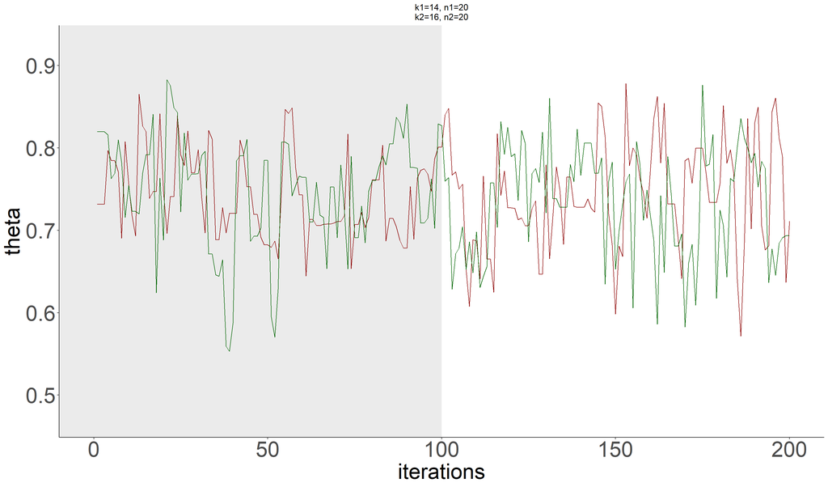

### 4.2.2 Plot (posterior)

The plot of the $\theta$ values per chain superimposed on each other.

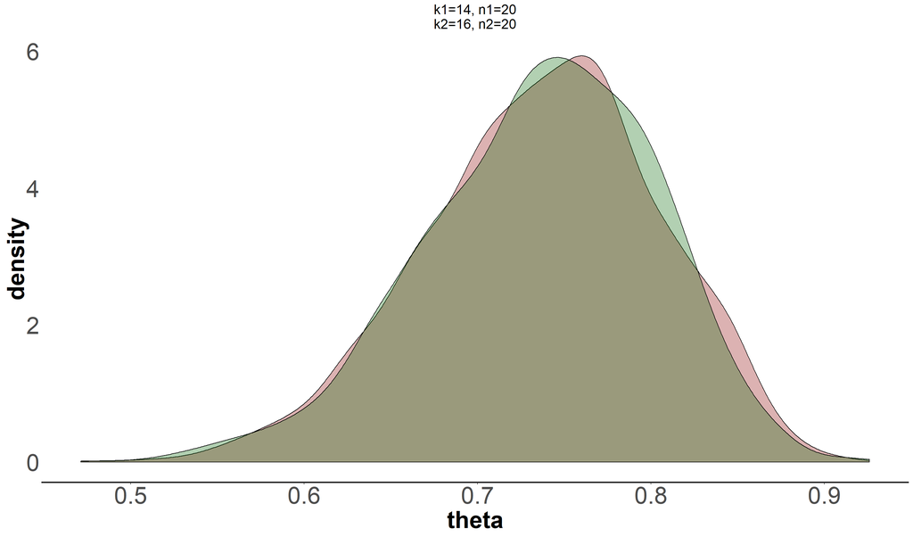

## 4.3 Confidence interval value and the measures of central tendency

The confidence interval values.

```
## # Highest Density Interval
##
##       95% HDI
##  [0.61, 0.86]
```

```
## # Equal-Tailed Interval
##
##       95% ETI
##  [0.59, 0.85]
```

The mean, median and mode values respectively

```
## [1] 0.7366359 0.7412578 0.7801850
```